# Risk Factor Analysis

## Outcome Variable

**Outcome Variable:** ever_stunted

## Predictor Variables

**Intervention Variable:** tr

**Adjustment Set:**

unadjusted

## Stratifying Variables

The analysis was stratified on these variable(s):

- cleanck
- agecat
- studyid
- country

## Data Summary

| cleanck | agecat | studyid | country | tr | ever_stunted | n_cell | n |
| --- | --- | --- | --- | --- | --- | --- | --- |
| 0 | 0-6 months | ki1000111-WASH-Kenya | KENYA | Control | 0 | 24 | 90 |
| 0 | 0-6 months | ki1000111-WASH-Kenya | KENYA | Control | 1 | 2 | 90 |
| 0 | 0-6 months | ki1000111-WASH-Kenya | KENYA | LNS | 0 | 23 | 90 |
| 0 | 0-6 months | ki1000111-WASH-Kenya | KENYA | LNS | 1 | 0 | 90 |
| 0 | 0-6 months | ki1000111-WASH-Kenya | KENYA | Other | 0 | 36 | 90 |
| 0 | 0-6 months | ki1000111-WASH-Kenya | KENYA | Other | 1 | 5 | 90 |
| 1 | 0-6 months | ki1000111-WASH-Kenya | KENYA | Control | 0 | 1 | 2 |
| 1 | 0-6 months | ki1000111-WASH-Kenya | KENYA | Other | 0 | 1 | 2 |
| 0 | 0-6 months | ki1000125-AgaKhanUniv | PAKISTAN | Control | 0 | 29 | 74 |
| 0 | 0-6 months | ki1000125-AgaKhanUniv | PAKISTAN | Control | 1 | 12 | 74 |
| 0 | 0-6 months | ki1000125-AgaKhanUniv | PAKISTAN | Maternal | 0 | 26 | 74 |
| 0 | 0-6 months | ki1000125-AgaKhanUniv | PAKISTAN | Maternal | 1 | 7 | 74 |
| 1 | 0-6 months | ki1000125-AgaKhanUniv | PAKISTAN | Control | 0 | 6 | 23 |
| 1 | 0-6 months | ki1000125-AgaKhanUniv | PAKISTAN | Control | 1 | 0 | 23 |
| 1 | 0-6 months | ki1000125-AgaKhanUniv | PAKISTAN | Maternal | 0 | 15 | 23 |
| 1 | 0-6 months | ki1000125-AgaKhanUniv | PAKISTAN | Maternal | 1 | 2 | 23 |
| 1 | 0-6 months | ki1000304-VITAMIN-A | INDIA | Control | 0 | 112 | 316 |
| 1 | 0-6 months | ki1000304-VITAMIN-A | INDIA | Control | 1 | 51 | 316 |
| 1 | 0-6 months | ki1000304-VITAMIN-A | INDIA | VitA | 0 | 100 | 316 |
| 1 | 0-6 months | ki1000304-VITAMIN-A | INDIA | VitA | 1 | 53 | 316 |
| 0 | 0-6 months | ki1000304-VITAMIN-A | INDIA | Control | 0 | 6 | 18 |
| 0 | 0-6 months | ki1000304-VITAMIN-A | INDIA | Control | 1 | 2 | 18 |
| 0 | 0-6 months | ki1000304-VITAMIN-A | INDIA | VitA | 0 | 9 | 18 |
| 0 | 0-6 months | ki1000304-VITAMIN-A | INDIA | VitA | 1 | 1 | 18 |
| 1 | 0-6 months | ki1017093b-PROVIDE | BANGLADESH | Control | 0 | 115 | 529 |
| 1 | 0-6 months | ki1017093b-PROVIDE | BANGLADESH | Control | 1 | 18 | 529 |
| 1 | 0-6 months | ki1017093b-PROVIDE | BANGLADESH | Other | 0 | 351 | 529 |
| 1 | 0-6 months | ki1017093b-PROVIDE | BANGLADESH | Other | 1 | 45 | 529 |
| 0 | 0-6 months | ki1017093b-PROVIDE | BANGLADESH | Control | 0 | 27 | 111 |
| 0 | 0-6 months | ki1017093b-PROVIDE | BANGLADESH | Control | 1 | 6 | 111 |

[output cut: 121 more lines]

The following strata were considered:

- cleanck: 0, agecat: 0-24 months, studyid: iLiNS_DYADM_LNS, country: MALAWI
- cleanck: 0, agecat: 0-24 months, studyid: ki1000111-WASH-Kenya, country: KENYA
- cleanck: 0, agecat: 0-24 months, studyid: ki1000125-AgaKhanUniv, country: PAKISTAN
- cleanck: 0, agecat: 0-24 months, studyid: ki1000304-VITAMIN-A, country: INDIA
- cleanck: 0, agecat: 0-24 months, studyid: ki1017093b-PROVIDE, country: BANGLADESH
- cleanck: 0, agecat: 0-24 months, studyid: ki1148112-iLiNS-DOSE, country: MALAWI
- cleanck: 0, agecat: 0-24 months, studyid: ki1148112-iLiNS-DYAD-M, country: MALAWI
- cleanck: 0, agecat: 0-6 months, studyid: iLiNS_DYADM_LNS, country: MALAWI
- cleanck: 0, agecat: 0-6 months, studyid: ki1000111-WASH-Kenya, country: KENYA
- cleanck: 0, agecat: 0-6 months, studyid: ki1000125-AgaKhanUniv, country: PAKISTAN
- cleanck: 0, agecat: 0-6 months, studyid: ki1000304-VITAMIN-A, country: INDIA
- cleanck: 0, agecat: 0-6 months, studyid: ki1017093b-PROVIDE, country: BANGLADESH
- cleanck: 0, agecat: 0-6 months, studyid: ki1148112-iLiNS-DOSE, country: MALAWI
- cleanck: 0, agecat: 0-6 months, studyid: ki1148112-iLiNS-DYAD-M, country: MALAWI
- cleanck: 0, agecat: 6-24 months, studyid: iLiNS_DYADM_LNS, country: MALAWI
- cleanck: 0, agecat: 6-24 months, studyid: ki1000111-WASH-Kenya, country: KENYA
- cleanck: 0, agecat: 6-24 months, studyid: ki1000125-AgaKhanUniv, country: PAKISTAN
- cleanck: 0, agecat: 6-24 months, studyid: ki1000304-VITAMIN-A, country: INDIA
- cleanck: 0, agecat: 6-24 months, studyid: ki1017093b-PROVIDE, country: BANGLADESH
- cleanck: 0, agecat: 6-24 months, studyid: ki1148112-iLiNS-DOSE, country: MALAWI
- cleanck: 0, agecat: 6-24 months, studyid: ki1148112-iLiNS-DYAD-M, country: MALAWI
- cleanck: 1, agecat: 0-24 months, studyid: iLiNS_DYADM_LNS, country: MALAWI
- cleanck: 1, agecat: 0-24 months, studyid: ki1000111-WASH-Kenya, country: KENYA
- cleanck: 1, agecat: 0-24 months, studyid: ki1000125-AgaKhanUniv, country: PAKISTAN
- cleanck: 1, agecat: 0-24 months, studyid: ki1000304-VITAMIN-A, country: INDIA
- cleanck: 1, agecat: 0-24 months, studyid: ki1017093b-PROVIDE, country: BANGLADESH
- cleanck: 1, agecat: 0-24 months, studyid: ki1148112-iLiNS-DOSE, country: MALAWI
- cleanck: 1, agecat: 0-24 months, studyid: ki1148112-iLiNS-DYAD-M, country: MALAWI
- cleanck: 1, agecat: 0-6 months, studyid: iLiNS_DYADM_LNS, country: MALAWI
- cleanck: 1, agecat: 0-6 months, studyid: ki1000111-WASH-Kenya, country: KENYA
- cleanck: 1, agecat: 0-6 months, studyid: ki1000125-AgaKhanUniv, country: PAKISTAN
- cleanck: 1, agecat: 0-6 months, studyid: ki1000304-VITAMIN-A, country: INDIA
- cleanck: 1, agecat: 0-6 months, studyid: ki1017093b-PROVIDE, country: BANGLADESH
- cleanck: 1, agecat: 0-6 months, studyid: ki1148112-iLiNS-DOSE, country: MALAWI
- cleanck: 1, agecat: 0-6 months, studyid: ki1148112-iLiNS-DYAD-M, country: MALAWI
- cleanck: 1, agecat: 6-24 months, studyid: iLiNS_DYADM_LNS, country: MALAWI
- cleanck: 1, agecat: 6-24 months, studyid: ki1000111-WASH-Kenya, country: KENYA
- cleanck: 1, agecat: 6-24 months, studyid: ki1000125-AgaKhanUniv, country: PAKISTAN
- cleanck: 1, agecat: 6-24 months, studyid: ki1000304-VITAMIN-A, country: INDIA
- cleanck: 1, agecat: 6-24 months, studyid: ki1017093b-PROVIDE, country: BANGLADESH
- cleanck: 1, agecat: 6-24 months, studyid: ki1148112-iLiNS-DOSE, country: MALAWI
- cleanck: 1, agecat: 6-24 months, studyid: ki1148112-iLiNS-DYAD-M, country: MALAWI

### Dropped Strata

Some strata were dropped due to rare outcomes:

- cleanck: 0, agecat: 0-6 months, studyid: ki1000111-WASH-Kenya, country: KENYA
- cleanck: 1, agecat: 0-6 months, studyid: ki1000111-WASH-Kenya, country: KENYA
- cleanck: 1, agecat: 0-6 months, studyid: ki1000125-AgaKhanUniv, country: PAKISTAN
- cleanck: 0, agecat: 0-6 months, studyid: ki1000304-VITAMIN-A, country: INDIA
- cleanck: 1, agecat: 0-6 months, studyid: ki1148112-iLiNS-DOSE, country: MALAWI
- cleanck: 0, agecat: 0-6 months, studyid: ki1148112-iLiNS-DYAD-M, country: MALAWI
- cleanck: 1, agecat: 0-6 months, studyid: ki1148112-iLiNS-DYAD-M, country: MALAWI
- cleanck: 1, agecat: 6-24 months, studyid: ki1000111-WASH-Kenya, country: KENYA
- cleanck: 0, agecat: 6-24 months, studyid: ki1000125-AgaKhanUniv, country: PAKISTAN
- cleanck: 1, agecat: 6-24 months, studyid: ki1000125-AgaKhanUniv, country: PAKISTAN
- cleanck: 0, agecat: 6-24 months, studyid: ki1000304-VITAMIN-A, country: INDIA
- cleanck: 1, agecat: 6-24 months, studyid: ki1148112-iLiNS-DYAD-M, country: MALAWI
- cleanck: 1, agecat: 0-24 months, studyid: ki1000111-WASH-Kenya, country: KENYA
- cleanck: 1, agecat: 0-24 months, studyid: ki1000125-AgaKhanUniv, country: PAKISTAN
- cleanck: 1, agecat: 0-24 months, studyid: ki1148112-iLiNS-DOSE, country: MALAWI
- cleanck: 1, agecat: 0-24 months, studyid: ki1148112-iLiNS-DYAD-M, country: MALAWI
- cleanck: 0, agecat: 0-6 months, studyid: iLiNS_DYADM_LNS, country: MALAWI
- cleanck: 1, agecat: 0-6 months, studyid: iLiNS_DYADM_LNS, country: MALAWI
- cleanck: 1, agecat: 6-24 months, studyid: iLiNS_DYADM_LNS, country: MALAWI
- cleanck: 1, agecat: 0-24 months, studyid: iLiNS_DYADM_LNS, country: MALAWI

## Methods Detail

We’re interested in the causal parameters $E[Y_a]$ for all values of $a \in \mathcal{A}$. These parameters represent the mean outcome if, possibly contrary to fact, we intervened to set all units to have $A=a$. Under the randomization and positivity assumptions, these are identified by the statistical parameters $\psi_a=E_W[E_{Y|A,W}(Y|A=a,W)]$. In addition, we’re interested in the mean of $Y$, $E[Y]$ under no intervention (the observed mean). We will estimate these parameters by using SuperLearner to fit the relevant likelihood factors – $E_{Y|A,W}(Y|A=a,W)$ and $p(A=a|W)$, and then updating our likelihood fit using a joint TMLE.

For unadjusted analyses ($W=\{\}$), initial likelihoods were estimated using Lrnr_glm to estimate the simple $E(Y|A)$ and Lrnr_mean to estimate $p(A)$. For adjusted analyses, a small library containing Lrnr_glmnet, Lrnr_xgboost, and Lrnr_mean was used.

Having estimated these parameters, we will then use the delta method to estimate relative risks and attributable risks relative to a prespecified baseline level of $A$.

```
##           ever_stunted
## tr         0
##   Control  0
##   LNS      5
##   Maternal 0
##   Other    0
##   VitA     0
```

# Results Detail

## Results Plots

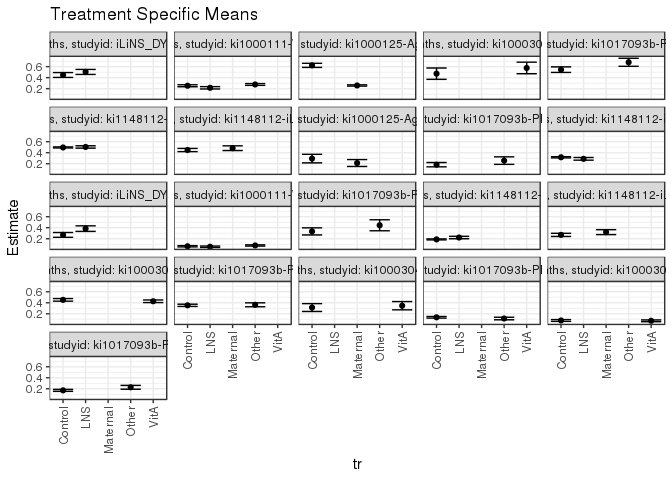

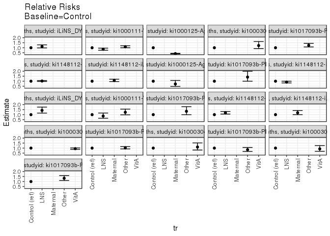

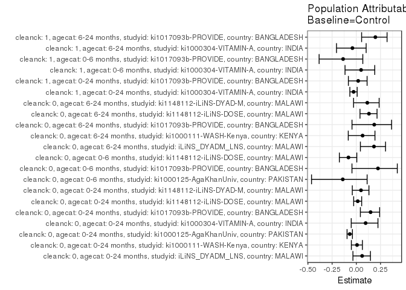

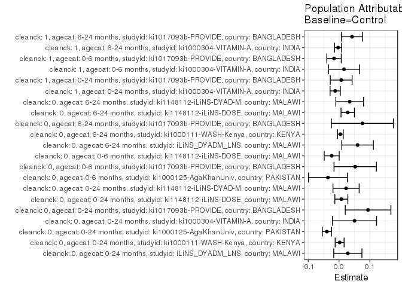

## Results Table

### Parameter: TSM

| cleanck | agecat | studyid | country | intervention_level | baseline_level | estimate | ci_lower | ci_upper |
| --- | --- | --- | --- | --- | --- | --- | --- | --- |
| 0 | 0-24 months | iLiNS_DYADM_LNS | MALAWI | Control | NA | 0.4482759 | 0.4038863 | 0.4926654 |
| 0 | 0-24 months | iLiNS_DYADM_LNS | MALAWI | LNS | NA | 0.5041322 | 0.4585531 | 0.5497113 |
| 0 | 0-24 months | ki1000111-WASH-Kenya | KENYA | Control | NA | 0.2528685 | 0.2349708 | 0.2707662 |
| 0 | 0-24 months | ki1000111-WASH-Kenya | KENYA | LNS | NA | 0.2154164 | 0.1942763 | 0.2365565 |
| 0 | 0-24 months | ki1000111-WASH-Kenya | KENYA | Other | NA | 0.2761739 | 0.2598295 | 0.2925184 |
| 0 | 0-24 months | ki1000125-AgaKhanUniv | PAKISTAN | Control | NA | 0.6237817 | 0.5863488 | 0.6612146 |
| 0 | 0-24 months | ki1000125-AgaKhanUniv | PAKISTAN | Maternal | NA | 0.2580645 | 0.2463101 | 0.2698189 |
| 0 | 0-24 months | ki1000304-VITAMIN-A | INDIA | Control | NA | 0.4725275 | 0.3696600 | 0.5753950 |
| 0 | 0-24 months | ki1000304-VITAMIN-A | INDIA | VitA | NA | 0.5764706 | 0.4711274 | 0.6818137 |
| 0 | 0-24 months | ki1017093b-PROVIDE | BANGLADESH | Control | NA | 0.5454545 | 0.4947187 | 0.5961904 |
| 0 | 0-24 months | ki1017093b-PROVIDE | BANGLADESH | Other | NA | 0.6794872 | 0.6063815 | 0.7525928 |
| 0 | 0-24 months | ki1148112-iLiNS-DOSE | MALAWI | Control | NA | 0.4950166 | 0.4855846 | 0.5044486 |
| 0 | 0-24 months | ki1148112-iLiNS-DOSE | MALAWI | LNS | NA | 0.5039947 | 0.4829247 | 0.5250646 |
| 0 | 0-24 months | ki1148112-iLiNS-DYAD-M | MALAWI | Control | NA | 0.4482759 | 0.4193156 | 0.4772362 |
| 0 | 0-24 months | ki1148112-iLiNS-DYAD-M | MALAWI | Maternal | NA | 0.4817814 | 0.4393223 | 0.5242404 |
| 0 | 0-6 months | ki1000125-AgaKhanUniv | PAKISTAN | Control | NA | 0.2926829 | 0.2149923 | 0.3703735 |
| 0 | 0-6 months | ki1000125-AgaKhanUniv | PAKISTAN | Maternal | NA | 0.2121212 | 0.1494960 | 0.2747465 |
| 0 | 0-6 months | ki1017093b-PROVIDE | BANGLADESH | Control | NA | 0.1818182 | 0.1425183 | 0.2211180 |
| 0 | 0-6 months | ki1017093b-PROVIDE | BANGLADESH | Other | NA | 0.2564103 | 0.1880078 | 0.3248128 |
| 0 | 0-6 months | ki1148112-iLiNS-DOSE | MALAWI | Control | NA | 0.3163842 | 0.3055615 | 0.3272069 |
| 0 | 0-6 months | ki1148112-iLiNS-DOSE | MALAWI | LNS | NA | 0.2881356 | 0.2637957 | 0.3124755 |
| 0 | 6-24 months | iLiNS_DYADM_LNS | MALAWI | Control | NA | 0.2696629 | 0.2258991 | 0.3134268 |
| 0 | 6-24 months | iLiNS_DYADM_LNS | MALAWI | LNS | NA | 0.3838384 | 0.3332574 | 0.4344194 |
| 0 | 6-24 months | ki1000111-WASH-Kenya | KENYA | Control | NA | 0.0628826 | 0.0516578 | 0.0741074 |
| 0 | 6-24 months | ki1000111-WASH-Kenya | KENYA | LNS | NA | 0.0542571 | 0.0414286 | 0.0670856 |
| 0 | 6-24 months | ki1000111-WASH-Kenya | KENYA | Other | NA | 0.0776786 | 0.0665930 | 0.0887641 |
| 0 | 6-24 months | ki1017093b-PROVIDE | BANGLADESH | Control | NA | 0.3333333 | 0.2686901 | 0.3979765 |
| 0 | 6-24 months | ki1017093b-PROVIDE | BANGLADESH | Other | NA | 0.4444444 | 0.3446978 | 0.5441911 |
| 0 | 6-24 months | ki1148112-iLiNS-DOSE | MALAWI | Control | NA | 0.1878173 | 0.1785669 | 0.1970676 |
| 0 | 6-24 months | ki1148112-iLiNS-DOSE | MALAWI | LNS | NA | 0.2217617 | 0.1999850 | 0.2435384 |
| 0 | 6-24 months | ki1148112-iLiNS-DYAD-M | MALAWI | Control | NA | 0.2696629 | 0.2409214 | 0.2984045 |
| 0 | 6-24 months | ki1148112-iLiNS-DYAD-M | MALAWI | Maternal | NA | 0.3197970 | 0.2748570 | 0.3647369 |
| 1 | 0-24 months | ki1000304-VITAMIN-A | INDIA | Control | NA | 0.4522968 | 0.4286197 | 0.4759739 |
| 1 | 0-24 months | ki1000304-VITAMIN-A | INDIA | VitA | NA | 0.4272019 | 0.4034662 | 0.4509376 |
| 1 | 0-24 months | ki1017093b-PROVIDE | BANGLADESH | Control | NA | 0.3533835 | 0.3329776 | 0.3737893 |
| 1 | 0-24 months | ki1017093b-PROVIDE | BANGLADESH | Other | NA | 0.3627204 | 0.3272612 | 0.3981796 |
| 1 | 0-6 months | ki1000304-VITAMIN-A | INDIA | Control | NA | 0.3128834 | 0.2415901 | 0.3841768 |
| 1 | 0-6 months | ki1000304-VITAMIN-A | INDIA | VitA | NA | 0.3464052 | 0.2708895 | 0.4219209 |
| 1 | 0-6 months | ki1017093b-PROVIDE | BANGLADESH | Control | NA | 0.1353383 | 0.1207077 | 0.1499690 |
| 1 | 0-6 months | ki1017093b-PROVIDE | BANGLADESH | Other | NA | 0.1136364 | 0.0902148 | 0.1370579 |
| 1 | 6-24 months | ki1000304-VITAMIN-A | INDIA | Control | NA | 0.0779727 | 0.0615622 | 0.0943832 |
| 1 | 6-24 months | ki1000304-VITAMIN-A | INDIA | VitA | NA | 0.0719770 | 0.0562807 | 0.0876732 |
| 1 | 6-24 months | ki1017093b-PROVIDE | BANGLADESH | Control | NA | 0.1714286 | 0.1538462 | 0.1890109 |
| 1 | 6-24 months | ki1017093b-PROVIDE | BANGLADESH | Other | NA | 0.2269939 | 0.1925603 | 0.2614275 |

### Parameter: E(Y)

| cleanck | agecat | studyid | country | intervention_level | baseline_level | estimate | ci_lower | ci_upper |
| --- | --- | --- | --- | --- | --- | --- | --- | --- |
| 0 | 0-24 months | iLiNS_DYADM_LNS | MALAWI | NA | NA | 0.4767932 | 0.4130706 | 0.5405159 |
| 0 | 0-24 months | ki1000111-WASH-Kenya | KENYA | NA | NA | 0.2547771 | 0.2442592 | 0.2652950 |
| 0 | 0-24 months | ki1000125-AgaKhanUniv | PAKISTAN | NA | NA | 0.5843478 | 0.5440304 | 0.6246653 |
| 0 | 0-24 months | ki1000304-VITAMIN-A | INDIA | NA | NA | 0.5227273 | 0.4487242 | 0.5967304 |
| 0 | 0-24 months | ki1017093b-PROVIDE | BANGLADESH | NA | NA | 0.6396396 | 0.5499199 | 0.7293594 |
| 0 | 0-24 months | ki1148112-iLiNS-DOSE | MALAWI | NA | NA | 0.5024958 | 0.4794106 | 0.5255811 |
| 0 | 0-24 months | ki1148112-iLiNS-DYAD-M | MALAWI | NA | NA | 0.4710744 | 0.4196539 | 0.5224948 |
| 0 | 0-6 months | ki1000125-AgaKhanUniv | PAKISTAN | NA | NA | 0.2567568 | 0.1565463 | 0.3569672 |
| 0 | 0-6 months | ki1017093b-PROVIDE | BANGLADESH | NA | NA | 0.2342342 | 0.1550890 | 0.3133795 |
| 0 | 0-6 months | ki1148112-iLiNS-DOSE | MALAWI | NA | NA | 0.2925959 | 0.2659514 | 0.3192404 |
| 0 | 6-24 months | iLiNS_DYADM_LNS | MALAWI | NA | NA | 0.3297872 | 0.2624042 | 0.3971703 |
| 0 | 6-24 months | ki1000111-WASH-Kenya | KENYA | NA | NA | 0.0672397 | 0.0604551 | 0.0740244 |
| 0 | 6-24 months | ki1017093b-PROVIDE | BANGLADESH | NA | NA | 0.4090909 | 0.2895651 | 0.5286167 |
| 0 | 6-24 months | ki1148112-iLiNS-DOSE | MALAWI | NA | NA | 0.2160069 | 0.1923356 | 0.2396782 |
| 0 | 6-24 months | ki1148112-iLiNS-DYAD-M | MALAWI | NA | NA | 0.3041958 | 0.2507829 | 0.3576087 |
| 1 | 0-24 months | ki1000304-VITAMIN-A | INDIA | NA | NA | 0.4398574 | 0.4230889 | 0.4566260 |
| 1 | 0-24 months | ki1017093b-PROVIDE | BANGLADESH | NA | NA | 0.3603774 | 0.3194644 | 0.4012903 |
| 1 | 0-6 months | ki1000304-VITAMIN-A | INDIA | NA | NA | 0.3291139 | 0.2772231 | 0.3810047 |
| 1 | 0-6 months | ki1017093b-PROVIDE | BANGLADESH | NA | NA | 0.1190926 | 0.0914653 | 0.1467199 |
| 1 | 6-24 months | ki1000304-VITAMIN-A | INDIA | NA | NA | 0.0749516 | 0.0636002 | 0.0863031 |
| 1 | 6-24 months | ki1017093b-PROVIDE | BANGLADESH | NA | NA | 0.2134571 | 0.1747286 | 0.2521855 |

### Parameter: RR

| cleanck | agecat | studyid | country | intervention_level | baseline_level | estimate | ci_lower | ci_upper |
| --- | --- | --- | --- | --- | --- | --- | --- | --- |
| 0 | 0-24 months | iLiNS_DYADM_LNS | MALAWI | Control | Control | 1.0000000 | 1.0000000 | 1.0000000 |
| 0 | 0-24 months | iLiNS_DYADM_LNS | MALAWI | LNS | Control | 1.1246027 | 0.9834795 | 1.2859761 |
| 0 | 0-24 months | ki1000111-WASH-Kenya | KENYA | Control | Control | 1.0000000 | 1.0000000 | 1.0000000 |
| 0 | 0-24 months | ki1000111-WASH-Kenya | KENYA | LNS | Control | 0.8518910 | 0.7548065 | 0.9614626 |
| 0 | 0-24 months | ki1000111-WASH-Kenya | KENYA | Other | Control | 1.0921642 | 0.9959086 | 1.1977230 |
| 0 | 0-24 months | ki1000125-AgaKhanUniv | PAKISTAN | Control | Control | 1.0000000 | 1.0000000 | 1.0000000 |
| 0 | 0-24 months | ki1000125-AgaKhanUniv | PAKISTAN | Maternal | Control | 0.4137097 | 0.3836868 | 0.4460818 |
| 0 | 0-24 months | ki1000304-VITAMIN-A | INDIA | Control | Control | 1.0000000 | 1.0000000 | 1.0000000 |
| 0 | 0-24 months | ki1000304-VITAMIN-A | INDIA | VitA | Control | 1.2199726 | 0.9181464 | 1.6210195 |
| 0 | 0-24 months | ki1017093b-PROVIDE | BANGLADESH | Control | Control | 1.0000000 | 1.0000000 | 1.0000000 |
| 0 | 0-24 months | ki1017093b-PROVIDE | BANGLADESH | Other | Control | 1.2457265 | 1.0805776 | 1.4361157 |
| 0 | 0-24 months | ki1148112-iLiNS-DOSE | MALAWI | Control | Control | 1.0000000 | 1.0000000 | 1.0000000 |
| 0 | 0-24 months | ki1148112-iLiNS-DOSE | MALAWI | LNS | Control | 1.0181369 | 0.9724186 | 1.0660047 |
| 0 | 0-24 months | ki1148112-iLiNS-DYAD-M | MALAWI | Control | Control | 1.0000000 | 1.0000000 | 1.0000000 |
| 0 | 0-24 months | ki1148112-iLiNS-DYAD-M | MALAWI | Maternal | Control | 1.0747431 | 0.9634925 | 1.1988393 |
| 0 | 0-6 months | ki1000125-AgaKhanUniv | PAKISTAN | Control | Control | 1.0000000 | 1.0000000 | 1.0000000 |
| 0 | 0-6 months | ki1000125-AgaKhanUniv | PAKISTAN | Maternal | Control | 0.7247475 | 0.4872640 | 1.0779760 |
| 0 | 0-6 months | ki1017093b-PROVIDE | BANGLADESH | Control | Control | 1.0000000 | 1.0000000 | 1.0000000 |
| 0 | 0-6 months | ki1017093b-PROVIDE | BANGLADESH | Other | Control | 1.4102564 | 1.0004255 | 1.9879772 |
| 0 | 0-6 months | ki1148112-iLiNS-DOSE | MALAWI | Control | Control | 1.0000000 | 1.0000000 | 1.0000000 |
| 0 | 0-6 months | ki1148112-iLiNS-DOSE | MALAWI | LNS | Control | 0.9107143 | 0.8313842 | 0.9976140 |
| 0 | 6-24 months | iLiNS_DYADM_LNS | MALAWI | Control | Control | 1.0000000 | 1.0000000 | 1.0000000 |
| 0 | 6-24 months | iLiNS_DYADM_LNS | MALAWI | LNS | Control | 1.4234007 | 1.1548784 | 1.7543575 |
| 0 | 6-24 months | ki1000111-WASH-Kenya | KENYA | Control | Control | 1.0000000 | 1.0000000 | 1.0000000 |
| 0 | 6-24 months | ki1000111-WASH-Kenya | KENYA | LNS | Control | 0.8628319 | 0.6415998 | 1.1603476 |
| 0 | 6-24 months | ki1000111-WASH-Kenya | KENYA | Other | Control | 1.2352955 | 0.9829192 | 1.5524725 |
| 0 | 6-24 months | ki1017093b-PROVIDE | BANGLADESH | Control | Control | 1.0000000 | 1.0000000 | 1.0000000 |
| 0 | 6-24 months | ki1017093b-PROVIDE | BANGLADESH | Other | Control | 1.3333333 | 0.9911119 | 1.7937206 |
| 0 | 6-24 months | ki1148112-iLiNS-DOSE | MALAWI | Control | Control | 1.0000000 | 1.0000000 | 1.0000000 |
| 0 | 6-24 months | ki1148112-iLiNS-DOSE | MALAWI | LNS | Control | 1.1807310 | 1.0578897 | 1.3178365 |
| 0 | 6-24 months | ki1148112-iLiNS-DYAD-M | MALAWI | Control | Control | 1.0000000 | 1.0000000 | 1.0000000 |
| 0 | 6-24 months | ki1148112-iLiNS-DYAD-M | MALAWI | Maternal | Control | 1.1859137 | 0.9941571 | 1.4146570 |
| 1 | 0-24 months | ki1000304-VITAMIN-A | INDIA | Control | Control | 1.0000000 | 1.0000000 | 1.0000000 |
| 1 | 0-24 months | ki1000304-VITAMIN-A | INDIA | VitA | Control | 0.9445167 | 0.8750983 | 1.0194420 |
| 1 | 0-24 months | ki1017093b-PROVIDE | BANGLADESH | Control | Control | 1.0000000 | 1.0000000 | 1.0000000 |
| 1 | 0-24 months | ki1017093b-PROVIDE | BANGLADESH | Other | Control | 1.0264216 | 0.9162547 | 1.1498345 |
| 1 | 0-6 months | ki1000304-VITAMIN-A | INDIA | Control | Control | 1.0000000 | 1.0000000 | 1.0000000 |
| 1 | 0-6 months | ki1000304-VITAMIN-A | INDIA | VitA | Control | 1.1071383 | 0.8076979 | 1.5175912 |
| 1 | 0-6 months | ki1017093b-PROVIDE | BANGLADESH | Control | Control | 1.0000000 | 1.0000000 | 1.0000000 |
| 1 | 0-6 months | ki1017093b-PROVIDE | BANGLADESH | Other | Control | 0.8396465 | 0.6653023 | 1.0596780 |
| 1 | 6-24 months | ki1000304-VITAMIN-A | INDIA | Control | Control | 1.0000000 | 1.0000000 | 1.0000000 |
| 1 | 6-24 months | ki1000304-VITAMIN-A | INDIA | VitA | Control | 0.9231046 | 0.6817566 | 1.2498921 |
| 1 | 6-24 months | ki1017093b-PROVIDE | BANGLADESH | Control | Control | 1.0000000 | 1.0000000 | 1.0000000 |
| 1 | 6-24 months | ki1017093b-PROVIDE | BANGLADESH | Other | Control | 1.3241309 | 1.1025694 | 1.5902151 |

### Parameter: PAR

| cleanck | agecat | studyid | country | intervention_level | baseline_level | estimate | ci_lower | ci_upper |
| --- | --- | --- | --- | --- | --- | --- | --- | --- |
| 0 | 0-24 months | iLiNS_DYADM_LNS | MALAWI | Control | NA | 0.0285174 | -0.0172007 | 0.0742355 |
| 0 | 0-24 months | ki1000111-WASH-Kenya | KENYA | Control | NA | 0.0019086 | -0.0126102 | 0.0164274 |
| 0 | 0-24 months | ki1000125-AgaKhanUniv | PAKISTAN | Control | NA | -0.0394339 | -0.0544097 | -0.0244580 |
| 0 | 0-24 months | ki1000304-VITAMIN-A | INDIA | Control | NA | 0.0501998 | -0.0213245 | 0.1217241 |
| 0 | 0-24 months | ki1017093b-PROVIDE | BANGLADESH | Control | NA | 0.0941851 | 0.0201885 | 0.1681817 |
| 0 | 0-24 months | ki1148112-iLiNS-DOSE | MALAWI | Control | NA | 0.0074792 | -0.0135913 | 0.0285498 |
| 0 | 0-24 months | ki1148112-iLiNS-DYAD-M | MALAWI | Control | NA | 0.0227985 | -0.0196910 | 0.0652881 |
| 0 | 0-6 months | ki1000125-AgaKhanUniv | PAKISTAN | Control | NA | -0.0359262 | -0.0992216 | 0.0273692 |
| 0 | 0-6 months | ki1017093b-PROVIDE | BANGLADESH | Control | NA | 0.0524161 | -0.0162825 | 0.1211146 |
| 0 | 0-6 months | ki1148112-iLiNS-DOSE | MALAWI | Control | NA | -0.0237883 | -0.0481357 | 0.0005591 |
| 0 | 6-24 months | iLiNS_DYADM_LNS | MALAWI | Control | NA | 0.0601243 | 0.0088876 | 0.1113610 |
| 0 | 6-24 months | ki1000111-WASH-Kenya | KENYA | Control | NA | 0.0043572 | -0.0048909 | 0.0136052 |
| 0 | 6-24 months | ki1017093b-PROVIDE | BANGLADESH | Control | NA | 0.0757576 | -0.0247794 | 0.1762945 |
| 0 | 6-24 months | ki1148112-iLiNS-DOSE | MALAWI | Control | NA | 0.0281896 | 0.0064006 | 0.0499786 |
| 0 | 6-24 months | ki1148112-iLiNS-DYAD-M | MALAWI | Control | NA | 0.0345329 | -0.0104877 | 0.0795535 |
| 1 | 0-24 months | ki1000304-VITAMIN-A | INDIA | Control | NA | -0.0124394 | -0.0290634 | 0.0041846 |
| 1 | 0-24 months | ki1017093b-PROVIDE | BANGLADESH | Control | NA | 0.0069939 | -0.0284669 | 0.0424547 |
| 1 | 0-6 months | ki1000304-VITAMIN-A | INDIA | Control | NA | 0.0162305 | -0.0340866 | 0.0665476 |
| 1 | 0-6 months | ki1017093b-PROVIDE | BANGLADESH | Control | NA | -0.0162457 | -0.0396810 | 0.0071896 |
| 1 | 6-24 months | ki1000304-VITAMIN-A | INDIA | Control | NA | -0.0030211 | -0.0144639 | 0.0084218 |
| 1 | 6-24 months | ki1017093b-PROVIDE | BANGLADESH | Control | NA | 0.0420285 | 0.0075212 | 0.0765358 |

### Parameter: PAF

| cleanck | agecat | studyid | country | intervention_level | baseline_level | estimate | ci_lower | ci_upper |
| --- | --- | --- | --- | --- | --- | --- | --- | --- |
| 0 | 0-24 months | iLiNS_DYADM_LNS | MALAWI | Control | NA | 0.0598108 | -0.0349936 | 0.1459312 |
| 0 | 0-24 months | ki1000111-WASH-Kenya | KENYA | Control | NA | 0.0074912 | -0.0511626 | 0.0628721 |
| 0 | 0-24 months | ki1000125-AgaKhanUniv | PAKISTAN | Control | NA | -0.0674835 | -0.0955432 | -0.0401426 |
| 0 | 0-24 months | ki1000304-VITAMIN-A | INDIA | Control | NA | 0.0960344 | -0.0524617 | 0.2235786 |
| 0 | 0-24 months | ki1017093b-PROVIDE | BANGLADESH | Control | NA | 0.1472471 | 0.0418900 | 0.2410188 |
| 0 | 0-24 months | ki1148112-iLiNS-DOSE | MALAWI | Control | NA | 0.0148842 | -0.0273028 | 0.0553386 |
| 0 | 0-24 months | ki1148112-iLiNS-DYAD-M | MALAWI | Control | NA | 0.0483969 | -0.0414814 | 0.1305188 |
| 0 | 0-6 months | ki1000125-AgaKhanUniv | PAKISTAN | Control | NA | -0.1399230 | -0.4626676 | 0.1116065 |
| 0 | 0-6 months | ki1017093b-PROVIDE | BANGLADESH | Control | NA | 0.2237762 | -0.0449169 | 0.4233768 |
| 0 | 0-6 months | ki1148112-iLiNS-DOSE | MALAWI | Control | NA | -0.0813008 | -0.1751819 | 0.0050805 |
| 0 | 6-24 months | iLiNS_DYADM_LNS | MALAWI | Control | NA | 0.1823124 | 0.0422034 | 0.3019259 |
| 0 | 6-24 months | ki1000111-WASH-Kenya | KENYA | Control | NA | 0.0648002 | -0.0832116 | 0.1925875 |
| 0 | 6-24 months | ki1017093b-PROVIDE | BANGLADESH | Control | NA | 0.1851852 | -0.0445359 | 0.3643845 |
| 0 | 6-24 months | ki1148112-iLiNS-DOSE | MALAWI | Control | NA | 0.1305034 | 0.0380226 | 0.2140934 |
| 0 | 6-24 months | ki1148112-iLiNS-DYAD-M | MALAWI | Control | NA | 0.1135219 | -0.0283893 | 0.2358502 |
| 1 | 0-24 months | ki1000304-VITAMIN-A | INDIA | Control | NA | -0.0282805 | -0.0667875 | 0.0088365 |
| 1 | 0-24 months | ki1017093b-PROVIDE | BANGLADESH | Control | NA | 0.0194072 | -0.0819962 | 0.1113071 |
| 1 | 0-6 months | ki1000304-VITAMIN-A | INDIA | Control | NA | 0.0493157 | -0.1165349 | 0.1905308 |
| 1 | 0-6 months | ki1017093b-PROVIDE | BANGLADESH | Control | NA | -0.1364125 | -0.3843217 | 0.0671003 |
| 1 | 6-24 months | ki1000304-VITAMIN-A | INDIA | Control | NA | -0.0403069 | -0.2046302 | 0.1016011 |
| 1 | 6-24 months | ki1017093b-PROVIDE | BANGLADESH | Control | NA | 0.1968944 | 0.0547949 | 0.3176311 |